# Basic examples of the ‘qplot’ function

By: Lawrence Lo https://lawrencelo.weebly.com/ Email: ollecnerwal180@gmail.com

These are notes from a ggplot2 presenation: https://www.youtube.com/watch?v=HeqHMM4ziXA&t=539s. This notebook gives the first few examples of using the ‘qplot’ function. The primary purpose of this document is to test R-notebook publishing online.

Let’s call the ‘ggplot2’ library and examine the first few rows of the sample data within the library, ‘mpg’.

```r
library(ggplot2)
head(mpg)
```

| manufacturer | model | displ | year | cyl | trans | drv | cty | hwy | fl | class |
| --- | --- | --- | --- | --- | --- | --- | --- | --- | --- | --- |
| audi | a4 | 1.8 | 1999 | 4 | auto(l5) | f | 18 | 29 | p | compact |
| audi | a4 | 1.8 | 1999 | 4 | manual(m5) | f | 21 | 29 | p | compact |
| audi | a4 | 2.0 | 2008 | 4 | manual(m6) | f | 20 | 31 | p | compact |
| audi | a4 | 2.0 | 2008 | 4 | auto(av) | f | 21 | 30 | p | compact |
| audi | a4 | 2.8 | 1999 | 6 | auto(l5) | f | 16 | 26 | p | compact |
| audi | a4 | 2.8 | 1999 | 6 | manual(m5) | f | 18 | 26 | p | compact |

The ‘str’ function gives some basic information of the variables in the data.

```r
str(mpg)
```

```
Classes ‘tbl_df’, ‘tbl’ and 'data.frame':   234 obs. of  11 variables:
 $ manufacturer: chr  "audi" "audi" "audi" "audi" ...
 $ model       : chr  "a4" "a4" "a4" "a4" ...
 $ displ       : num  1.8 1.8 2 2 2.8 2.8 3.1 1.8 1.8 2 ...
 $ year        : int  1999 1999 2008 2008 1999 1999 2008 1999 1999 2008 ...
 $ cyl         : int  4 4 4 4 6 6 6 4 4 4 ...
 $ trans       : chr  "auto(l5)" "manual(m5)" "manual(m6)" "auto(av)" ...
 $ drv         : chr  "f" "f" "f" "f" ...
 $ cty         : int  18 21 20 21 16 18 18 18 16 20 ...
 $ hwy         : int  29 29 31 30 26 26 27 26 25 28 ...
 $ fl          : chr  "p" "p" "p" "p" ...
 $ class       : chr  "compact" "compact" "compact" "compact" ...
```

The ‘qplot’ function is simplified, easy to use function that can produce plots within a single function call. Here is a basic scatterplot of displacement (‘disp’), an indicator of engine size, against a car’s highway mileage (‘hwy’)

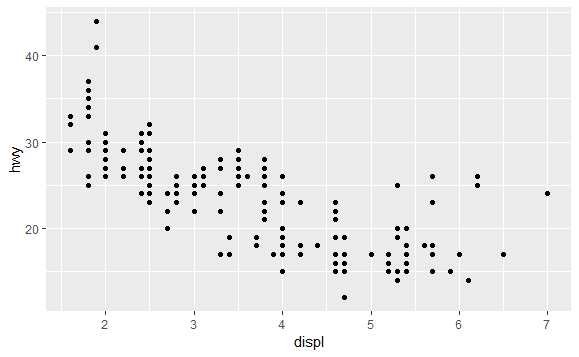

```r
qplot(displ, hwy, data = mpg)
```

Adding a ‘color’ argument to the function call can now specifiy which cars are 4-wheel drive, rear-wheal, or front-wheel drive.

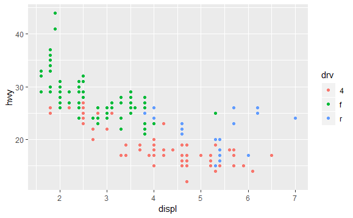

```r
qplot(displ, hwy, data = mpg, color = drv)
```

Here we use the ‘geom’ argument to add other geometric features to the plot. Here we add a loess-smoothed line showing a trend with 95% confidence intervals.

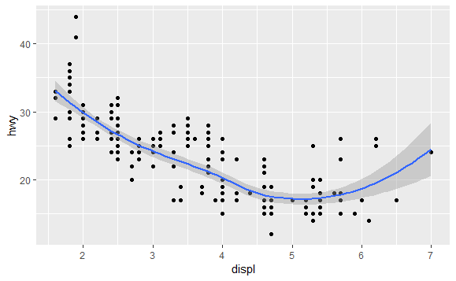

```r
qplot(displ, hwy, data = mpg, geom = c("point","smooth"))
```

We can use ‘qplot’ to generate a variety of plot types, including histograms. Let’s examine the distribution of cars by mileage, separating them by drive-type.

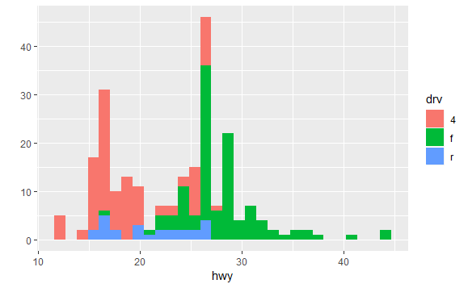

```r
qplot(hwy, data = mpg, fill = drv)
```

Instead of including the drive-type variable divided by color within a single variable, we can create faceted or paneled plots. The facets argument should take a ‘row~column’ specification

Here is the same engine size by mileage scatterplot divided into drive-types by columned facets rather than color.

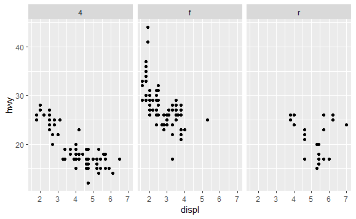

```r
qplot(displ, hwy, data = mpg, facets = .~drv)
```

We can approach the histogram plot similarly, dividing drive-type by rowed plots.

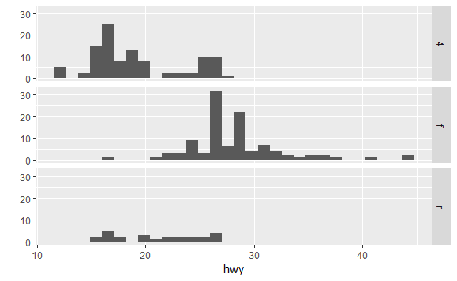

```r
qplot(hwy, data = mpg, facets = drv~.)
```